#### 11.03.24, © [Evhenii Kostin](https://www.linkedin.com/in/%D0%B5%D0%B2%D0%B3%D0%B5%D0%BD%D0%B8%D0%B9-%D0%BA%D0%BE%D1%81%D1%82%D0%B8%D0%BD-8287b0264/), 2024

# Лабораторна робота №6. Метод головних компонент. Метричні методи класифікації

# Завдання для самостійної роботи

```
Точність класифікації методом k найближчих сусідів: 0.50
Таблиця частот точності класифікації:
--------------------------------------------------
| Клас | Правильно класифіковано | Неправильно класифіковано |
--------------------------------------------------
|  -1  |             1             |              4               |
|  1  |             4             |              1               |
--------------------------------------------------
```

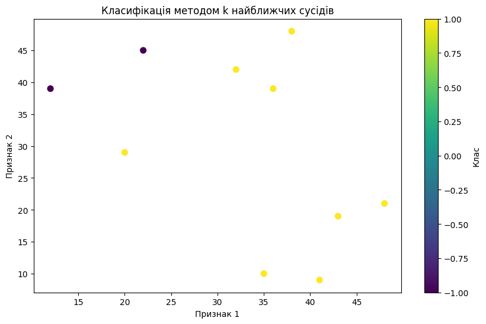

```python
import numpy as np
import matplotlib.pyplot as plt
from sklearn.neighbors import KNeighborsClassifier
from sklearn.metrics import accuracy_score

# Ваші дані
x_train_9 = np.array([[37, 46], [26, 50], [23, 6], [21, 33], [36, 42], [37, 44], [19, 6], [23, 5], [35, 28]])
y_train_9 = np.array([1, -1, 1, 1, -1, 1, -1, 1, 1])

# Тестовий набір даних
x_test_9 = np.array([[35, 10], [36, 39], [41, 9], [43, 19], [32, 42], [38, 48], [12, 39], [22, 45], [20, 29], [48, 21]])
y_test_9 = np.array([-1, -1, -1, 1, 1, 1, -1, 1, -1, 1])

# Визначення класифікатора та навчання моделі
k = 3  # Кількість найближчих сусідів
knn = KNeighborsClassifier(n_neighbors=k)
knn.fit(x_train_9, y_train_9)

# Прогнозування класів для тестових даних
y_pred_9 = knn.predict(x_test_9)

# Оцінка точності класифікації
accuracy_9 = accuracy_score(y_test_9, y_pred_9)
print(f"Точність класифікації методом k найближчих сусідів: {accuracy_9:.2f}")

# Вивід таблиці частот точності класифікації
print("Таблиця частот точності класифікації:")
print("--------------------------------------------------")
print("| Клас | Правильно класифіковано | Неправильно класифіковано |")
print("--------------------------------------------------")
for target in np.unique(y_test_9):
    correct = np.sum((y_test_9 == target) & (y_pred_9 == target))
    incorrect = np.sum((y_test_9 == target) & (y_pred_9 != target))
    print(f"|  {target}  | {correct:^25} | {incorrect:^28} |")
print("--------------------------------------------------")

# Візуалізація
plt.figure(figsize=(10, 6))
plt.scatter(x_test_9[:, 0], x_test_9[:, 1], c=y_pred_9, cmap='viridis', s=50)
plt.title('Класифікація методом k найближчих сусідів')
plt.xlabel('Признак 1')
plt.ylabel('Признак 2')
plt.colorbar(label='Клас')
plt.show()
```

## Відповіді на контрольні запитання

#### 1.Ідея методу головних компонент (PCA):

*PCA - це статистичний метод, який використовується для зменшення розмірності даних шляхом проектування їх на простір меншої розмірності зберігаючи при цьому якнайбільше можливу дисперсію.*

#### 3.Пов'язаність PCA та SVD:

*PCA можна виконати за допомогою методу SVD (розкладу з використанням сингулярних значень). Він полягає в розкладі матриці даних на добуток трьох матриць, що дозволяє отримати головні компоненти.*

#### 4.Метрики якості в багатокласовій класифікації:

*Для оцінки класифікатора використовуються такі метрики як точність, відновлення, F1-міра, матриця плутанини тощо.*

#### 5.Відмінності стратегій one-vs-all та all-vs-all у багатокласовій класифікації:

*В стратегії one-vs-all для кожного класу тренується класифікатор, який відрізняє цей клас від всіх інших. У стратегії all-vs-all тренується класифікатор для кожної пари класів.*

#### 6.Гіпотеза компактності в метричних методах класифікації:

*Гіпотеза компактності стверджує, що схожі об'єкти мають схожі класи.*

#### 7.Метод k-найближчих сусідів (kNN):

*kNN класифікує нові об'єкти, порівнюючи їх з k найближчими об'єктами з навчального набору. Він має високу точність на навчальних даних, але може виявитися неефективним на великих об'ємах даних.*

#### 8.Суть методу парзенівського вікна:

*Метод парзенівського вікна використовує ваговану суму класів навколо тестового об'єкта для прийняття рішення про класифікацію. Розмір вікна визначається вручну або автоматично.*

#### 9.Суть методу потенційних функцій у метричних методах класифікації:

*Метод потенційних функцій використовує функцію відстані для призначення ваг класам. Об'єктам з низькою відстанню до точок навчання надається більше ваги при класифікації.*

[figure not shown]

Created in Deepnote